## Размерная структура

Вот средине и размех варьирования по каждому году

| Year | Mean_L | SD | Min | Max |
| --- | --- | --- | --- | --- |
| 2007 | 33.00240 | 5.335371 | 22.8 | 60.5 |
| 2008 | 32.10000 | 7.423668 | 25.2 | 75.0 |
| 2009 | 31.45657 | 5.623931 | 24.6 | 56.8 |
| 2010 | 33.56410 | 4.423293 | 26.6 | 46.8 |
| 2012 | 33.27255 | 5.064705 | 25.9 | 60.2 |
| 2013 | 34.40882 | 6.925590 | 28.1 | 69.7 |
| 2014 | 33.99437 | 7.067893 | 23.2 | 69.5 |
| 2015 | 31.44841 | 3.995752 | 22.8 | 57.3 |
| 2016 | 32.59231 | 3.658864 | 27.1 | 43.1 |
| 2017 | 31.35886 | 3.850801 | 23.3 | 57.3 |
| 2018 | 32.36722 | 4.248397 | 23.2 | 57.4 |
| 2019 | 34.57386 | 4.531968 | 25.0 | 48.4 |
| 2021 | 33.70781 | 4.748603 | 23.3 | 51.8 |
| 2022 | 33.76049 | 6.017198 | 22.1 | 65.7 |
| 2023 | 33.02602 | 6.226146 | 25.0 | 82.1 |
| 2024 | 31.85580 | 4.140033 | 24.3 | 57.3 |
| 2025 | 33.23522 | 4.056549 | 25.7 | 56.6 |

По всему материалу

| Mean_L | SD | Min | Max |
| --- | --- | --- | --- |
| 32.63439 | 5.012195 | 22.1 | 82.1 |

Вот результаты подбора этой модели.

```
##
## Family: gaussian
## Link function: identity
##
## Formula:
## L ~ s(Year) + s(DOY, k = 5)
##
## Parametric coefficients:
##             Estimate Std. Error t value Pr(>|t|)
## (Intercept)  32.6344     0.1062   307.4   <2e-16 ***
## ---
## Signif. codes:  0 '***' 0.001 '**' 0.01 '*' 0.05 '.' 0.1 ' ' 1
##
## Approximate significance of smooth terms:
##           edf Ref.df     F p-value
## s(Year) 7.463  8.359 5.715  <2e-16 ***
## s(DOY)  1.298  1.536 2.497  0.0664 .
## ---
## Signif. codes:  0 '***' 0.001 '**' 0.01 '*' 0.05 '.' 0.1 ' ' 1
##
## R-sq.(adj) =  0.0258   Deviance explained = 2.97%
## GCV = 24.586  Scale est. = 24.475    n = 2172
```

Видно, что значимой связи с сезоном нет, но если этот вопрос поднимать, то придется объяснять что-то про динамику размера.

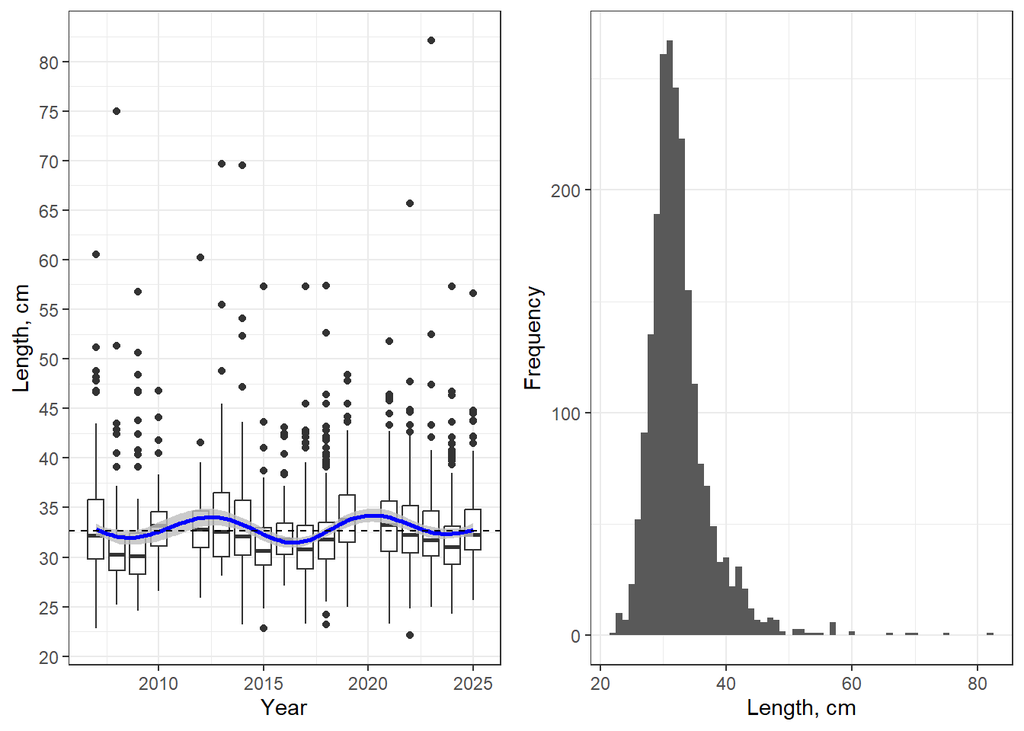

Здесь, на левом графике, линия (с 95% доверительным интервалом) отражает предсказанные моделью значения.

НО!!! Петр, это все сделано БЕЗ выбрасывания 2016 года. Если его выкинуть, то произойдут некоторые довольно важные изменения. Зависимость от дня года (DOY) станет значимой. И ее уже игнорить будет нельзя. Вот посмотри, что получается.

Вот средине и размех варьирования по каждому году

| Year | Mean_L | SD | Min | Max |
| --- | --- | --- | --- | --- |
| 2007 | 33.00240 | 5.335371 | 22.8 | 60.5 |
| 2008 | 32.10000 | 7.423668 | 25.2 | 75.0 |
| 2009 | 31.45657 | 5.623931 | 24.6 | 56.8 |
| 2010 | 33.56410 | 4.423293 | 26.6 | 46.8 |
| 2012 | 33.27255 | 5.064705 | 25.9 | 60.2 |
| 2013 | 34.40882 | 6.925590 | 28.1 | 69.7 |
| 2014 | 33.99437 | 7.067893 | 23.2 | 69.5 |
| 2015 | 31.44841 | 3.995752 | 22.8 | 57.3 |
| 2017 | 31.35886 | 3.850801 | 23.3 | 57.3 |
| 2018 | 32.36722 | 4.248397 | 23.2 | 57.4 |
| 2019 | 34.57386 | 4.531968 | 25.0 | 48.4 |
| 2021 | 33.70781 | 4.748603 | 23.3 | 51.8 |
| 2022 | 33.76049 | 6.017198 | 22.1 | 65.7 |
| 2023 | 33.02602 | 6.226146 | 25.0 | 82.1 |
| 2024 | 31.85580 | 4.140033 | 24.3 | 57.3 |
| 2025 | 33.23522 | 4.056549 | 25.7 | 56.6 |

По всему материалу

| Mean_L | SD | Min | Max |
| --- | --- | --- | --- |
| 32.63569 | 5.04882 | 22.1 | 82.1 |

Вот результаты подбора этой модели.

```
##
## Family: gaussian
## Link function: identity
##
## Formula:
## L ~ s(Year) + s(DOY, k = 8)
##
## Parametric coefficients:
##             Estimate Std. Error t value Pr(>|t|)
## (Intercept)  32.6357     0.1083   301.3   <2e-16 ***
## ---
## Signif. codes:  0 '***' 0.001 '**' 0.01 '*' 0.05 '.' 0.1 ' ' 1
##
## Approximate significance of smooth terms:
##           edf Ref.df     F p-value
## s(Year) 7.543  8.411 6.432  <2e-16 ***
## s(DOY)  1.877  2.376 3.325  0.0298 *
## ---
## Signif. codes:  0 '***' 0.001 '**' 0.01 '*' 0.05 '.' 0.1 ' ' 1
##
## R-sq.(adj) =  0.0301   Deviance explained = 3.44%
## GCV = 24.847  Scale est. = 24.725    n = 2107
```

Видно, что теперь некоторая связь размера с сезоном читается. Она выглядит довольно понятно: чем ближе к осени, тем крупнее рыбы. Должны же они расти в течение лета.

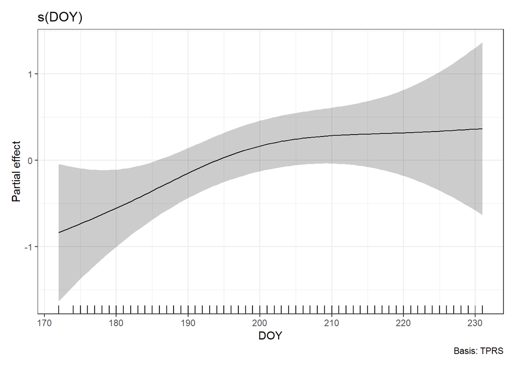

На всех остальных результатах это не отражается, так как там вежде в качестве ковариаты вставляется размер.

Если ипрнимаем такой вариант (без учета 2016 года), то предлагаю вот такую картинку.

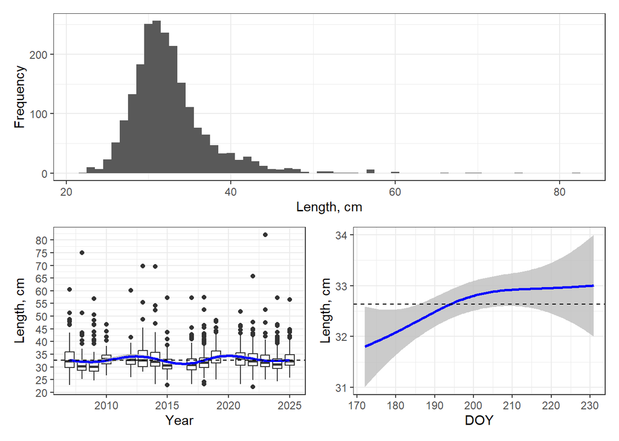

Тогда придется написать про то, что межгодовые колебания хоть и статистически значимы, но несущественны, все вокруг среднего. Сезонная динамика связана с ростом.

# Общее описание рациона

## Таблица с характеристиками питания

Вместо двух таблиц (средний вес объекта в пищевом комке и встречаемость, % в отдельные годы) нужно сделать одну таблицу (средние величины за все годы 2007-2025) по форме, приведнной ниже.

| Group | Sci_name | Freq | Prop |
| --- | --- | --- | --- |
| Polychaeta | Nereidinae (Nereis pelagica + Alitta virens) | 15.19 | 11.62 |
| Crustacea | Anonyx nugax | + | 0.15 |
| Crustacea | Crustacea remains | + | 0.09 |
| Crustacea | Eualus gaimardii | 2.66 | 0.28 |
| Crustacea | Hyas araneus | 0.14 | 0.29 |
| Crustacea | Mysidacea | + | 0.06 |
| Crustacea | Pandalus montagui | + | 0.14 |
| Crustacea | Pandalus montagui | + | 0.14 |
| Crustacea | Paroediceros propinguus | + | 0.00 |
| Crustacea | Pagurus pubescens | + | 0.09 |
| Crustacea | Rhachotropis aculeata | + | 0.05 |
| Crustacea | Sclerocrangon boreas | 2.47 | 1.66 |
| Crustacea | Sabinea septemcarinata | + | 0.05 |
| Ophiuroidea | Ophiopholis aculeata | 4.94 | 2.73 |
| Ophiuroidea | Ophiura robusta | 0.62 | 0.23 |
| Holothuroidea | Ekmania barthii | + | 0.02 |
| Pisces | Agonuscataphractus | + | 0.14 |
| Pisces | Ammodytes marinus | 2.75 | 4.32 |
| Pisces | Cyclopterus lumpus | + | 0.02 |
| Pisces | Clupeapallasii marisalbi | 5.22 | 15.27 |
| Pisces | Fisheggs | 12.2 | 13.90 |
| Pisces | Gasterosteus.aculeatus | 34.36 | 32.83 |
| Pisces | Gadus morhuamarisalbi | 1.28 | 3.21 |
| Pisces | Limandalimanda | 1.57 | 2.14 |
| Pisces | Lumpenus sp. | 3.18 | 4.14 |
| Pisces | Myoxocephalus scorpuis | 1.19 | 1.50 |
| Pisces | Mallotusvillosus | 0.28 | 1.35 |
| Pisces | Pholis gunnelus | 1.42 | 1.80 |
| Pisces | Fish remains | 2.52 | 1.91 |

Вот данные по отдельным группам. Это проще вставить руками в таблицу.

НО! проверь правильно ли я посчитал. У меня есть сомнения.

| Group | Freq | Prop |
| --- | --- | --- |
| Polychaeta | 15.19 | 58.96 |
| Crustacea | 0.8 | 1.26 |
| Ophiuroidea | 2.78 | 7.47 |
| Holothuroidea | + | 0.08 |
| Pisces | 5.08 | 32.23 |

## Динамика пустых желудков

At! убрал 2016 год!

Модель, котрую строим имеет следующий вид

Empty ~ s(Year) + s(DOY) + s(L), data = total_weight, family = “binomial”

Вот результаты подбора модели

```
##
## Family: binomial
## Link function: logit
##
## Formula:
## Empty ~ s(Year) + s(DOY) + s(L)
##
## Parametric coefficients:
##             Estimate Std. Error z value Pr(>|z|)
## (Intercept) -1.11507    0.05224  -21.34   <2e-16 ***
## ---
## Signif. codes:  0 '***' 0.001 '**' 0.01 '*' 0.05 '.' 0.1 ' ' 1
##
## Approximate significance of smooth terms:
##           edf Ref.df Chi.sq  p-value
## s(Year) 7.297  8.243 33.553 6.51e-05 ***
## s(DOY)  6.864  7.906 68.389  < 2e-16 ***
## s(L)    3.338  4.205  5.382    0.286
## ---
## Signif. codes:  0 '***' 0.001 '**' 0.01 '*' 0.05 '.' 0.1 ' ' 1
##
## R-sq.(adj) =  0.0465   Deviance explained = 4.79%
## UBRE = 0.1042  Scale est. = 1         n = 2107
```

Статистически значимыми была как многолетняя динамика, так и сезонные изменения, но связи с размерами не выявлется.

Вот визуализация модели

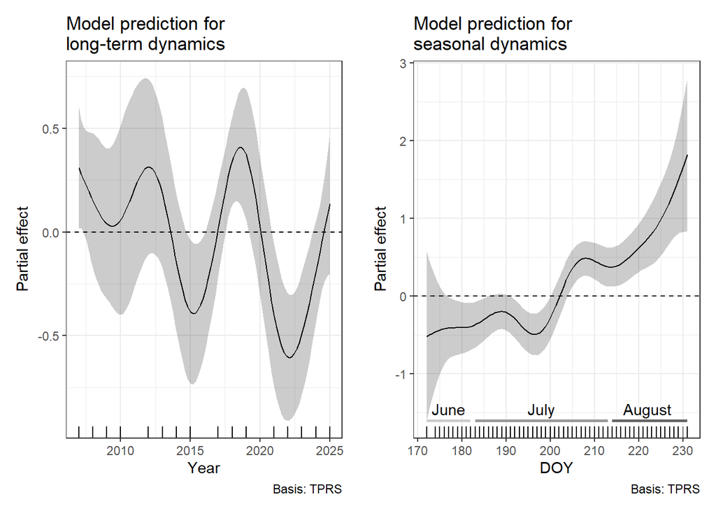

На этих рисунках, как и везде, горизонтальная пунктирная линия отражает среднее по популяции значение. Ниже нуля - меньше среднего и наоборот.

+++++++++++++++++++++

Нужны средние по доле особей с пустыми желудками по отдельным годам для конкретики. Из рисунков, приведенных выше, этих данных не видно.

| Year | Prop_empty |
| --- | --- |
| 2007 | 36.40 |
| 2008 | 20.00 |
| 2009 | 26.26 |
| 2010 | 23.08 |
| 2012 | 19.61 |
| 2013 | 33.82 |
| 2014 | 28.17 |
| 2015 | 12.70 |
| 2017 | 22.07 |
| 2018 | 33.61 |
| 2019 | 28.41 |
| 2021 | 17.97 |
| 2022 | 32.10 |
| 2023 | 14.63 |
| 2024 | 22.32 |
| 2025 | 29.56 |

## Динамика веса пищевого комка в заполненных желудках

Анализируем общий вес пищи в желудках

Модель, котрую строим имеет следующий вид

Total_Weight ~ s(Year) + s(DOY) + s(L)

Вот результаты подбора модели

```
##
## Family: gaussian
## Link function: identity
##
## Formula:
## Total_Weight ~ s(Year) + s(DOY) + s(L, k = 5)
##
## Parametric coefficients:
##             Estimate Std. Error t value Pr(>|t|)
## (Intercept)   8.6887     0.2271   38.26   <2e-16 ***
## ---
## Signif. codes:  0 '***' 0.001 '**' 0.01 '*' 0.05 '.' 0.1 ' ' 1
##
## Approximate significance of smooth terms:
##           edf Ref.df      F p-value
## s(Year) 6.839  7.877  4.588 1.5e-05 ***
## s(DOY)  1.867  2.366  1.237   0.333
## s(L)    3.662  3.934 37.909 < 2e-16 ***
## ---
## Signif. codes:  0 '***' 0.001 '**' 0.01 '*' 0.05 '.' 0.1 ' ' 1
##
## R-sq.(adj) =  0.106   Deviance explained = 11.3%
## GCV = 81.365  Scale est. = 80.669    n = 1564
```

At! Данные за 2016 убрал.

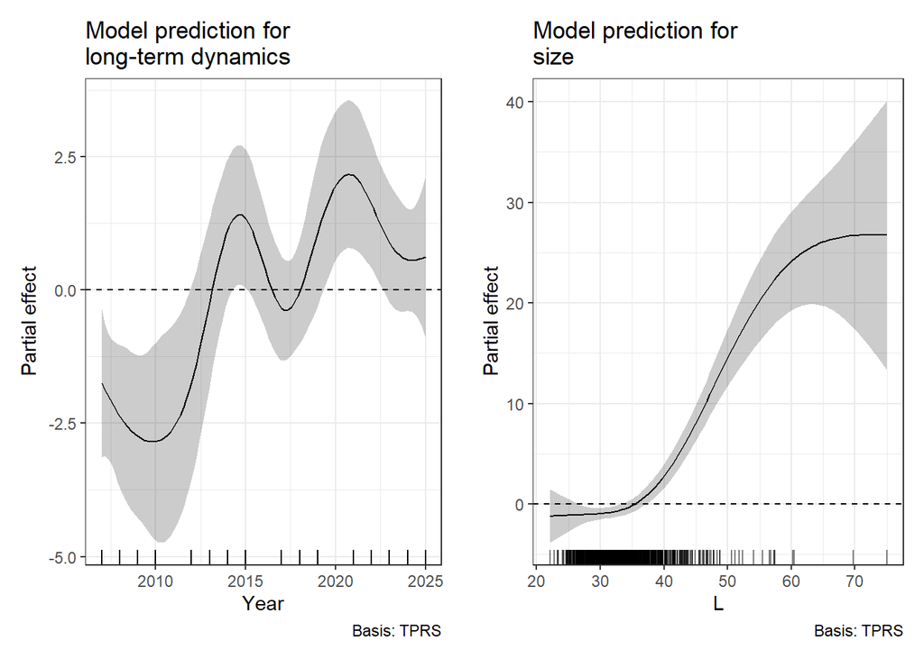

## Состав пищевого комка

## Динамика встречаемости пищевых объектов

Ранжируем виды по их встречаемости (за все годы исследования)

```
## [1] "G.aculeatus"          "Nereis_spp."          "Fish_eggs"
## [4] "C.pallasii_marisalbi" "O.aculeata"
```

Для этих видов будем строить модель многолетней и сезонной динамики встречаемости.

Модель имеет следующий вид

Presence ~ s(Year, by = Species) + s(DOY, by = Species) + s(L, by = Species, k =5) + Species

То есть мы сразу очениваем и многолетнюю динамику, и сезонную динамику и связь с размерами.

Вот результаты этой модели

```
##
## Family: binomial
## Link function: logit
##
## Formula:
## Presence ~ s(Year, by = Species, k = 5) + s(DOY, by = Species,
##     k = 5) + s(L, by = Species, k = 5) + Species
##
## Parametric coefficients:
##                             Estimate Std. Error z value Pr(>|z|)
## (Intercept)                 -0.21383    0.05600  -3.818 0.000134 ***
## SpeciesC.pallasii_marisalbi -2.69269    0.13831 -19.468  < 2e-16 ***
## SpeciesFish_eggs            -1.82159    0.11468 -15.884  < 2e-16 ***
## SpeciesO.aculeata           -2.51445    0.12297 -20.447  < 2e-16 ***
## SpeciesNereis_spp.          -1.39877    0.09545 -14.655  < 2e-16 ***
## ---
## Signif. codes:  0 '***' 0.001 '**' 0.01 '*' 0.05 '.' 0.1 ' ' 1
##
## Approximate significance of smooth terms:
##                                       edf Ref.df Chi.sq  p-value
## s(Year):SpeciesG.aculeatus          1.952  2.354  8.697 0.017556 *
## s(Year):SpeciesC.pallasii_marisalbi 3.956  3.999 41.817  < 2e-16 ***
## s(Year):SpeciesFish_eggs            1.000  1.001  4.285 0.038529 *
## s(Year):SpeciesO.aculeata           1.000  1.001  0.439 0.507895
## s(Year):SpeciesNereis_spp.          3.946  3.998 78.940  < 2e-16 ***
## s(DOY):SpeciesG.aculeatus           3.148  3.593 99.260  < 2e-16 ***
## s(DOY):SpeciesC.pallasii_marisalbi  2.917  3.442 18.687 0.000539 ***
## s(DOY):SpeciesFish_eggs             3.226  3.649 71.238  < 2e-16 ***
## s(DOY):SpeciesO.aculeata            3.376  3.788 14.608 0.003601 **
## s(DOY):SpeciesNereis_spp.           3.951  3.998 82.526  < 2e-16 ***
## s(L):SpeciesG.aculeatus             3.348  3.774 68.306  < 2e-16 ***
## s(L):SpeciesC.pallasii_marisalbi    1.000  1.001  7.846 0.005103 **
## s(L):SpeciesFish_eggs               3.421  3.820 56.745  < 2e-16 ***
## s(L):SpeciesO.aculeata              1.001  1.001  4.029 0.044772 *
## s(L):SpeciesNereis_spp.             1.000  1.001 10.223 0.001390 **
## ---
## Signif. codes:  0 '***' 0.001 '**' 0.01 '*' 0.05 '.' 0.1 ' ' 1
##
## R-sq.(adj) =  0.222   Deviance explained = 21.9%
## UBRE = -0.22123  Scale est. = 1         n = 7820
```

Не выявлена многолетняя динамика только у O.aculeata (!!! Отличается от предыдущего результата, когда 2016 использовал).

Связь с размерами есть у всех (!!! Отличается от предыдущего результата).

**Встречаемость видов в зависимости от размеров трески**

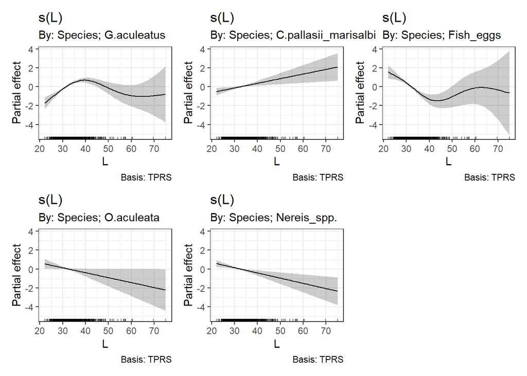

**Сезонная динамика встречаемости видов**

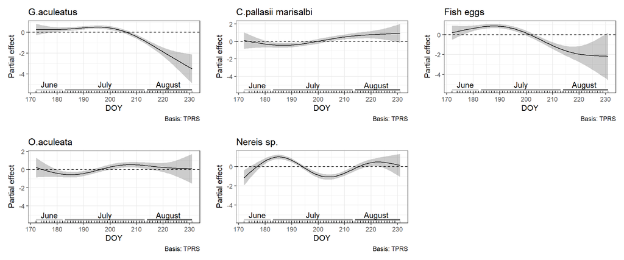

Первую половину лета треска ест колюшку и икру, вторую половину лета - селедку и, возможно, офиур. С нереисами сложнее. Первый пик - это явно период хода нереиса в первой половине лета. Второй пик - может это другой вид нереиса? Надо поискать данные по периодам хода у pelgica и virens.

**Многолетняя динамика встречаемости видов**

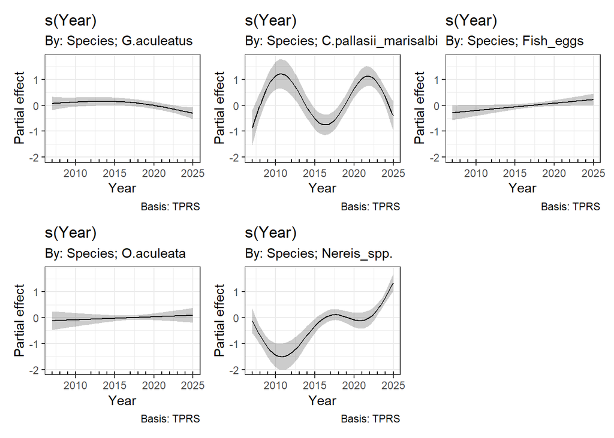

## Динамика доли пищевых объектов

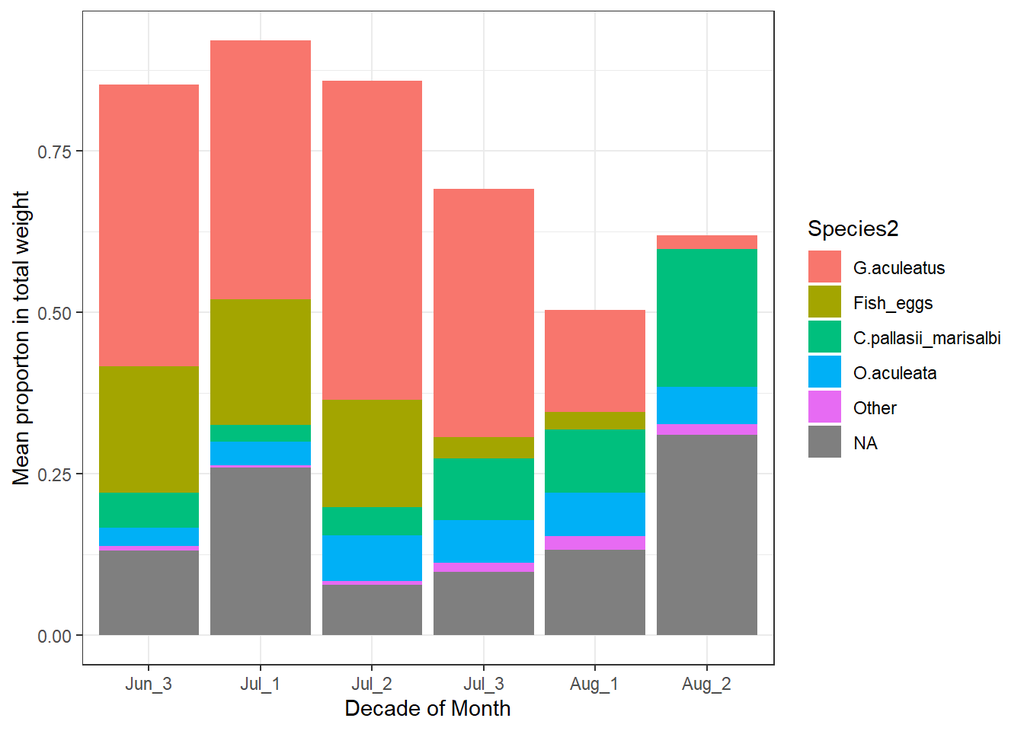

# Новый кусок

## Другой способ вычисления доли

За 100% берется вся сумма весов жертв за декаду. Далее на графике отражаем долю суммы каждого вида в общей сумме за декаду.

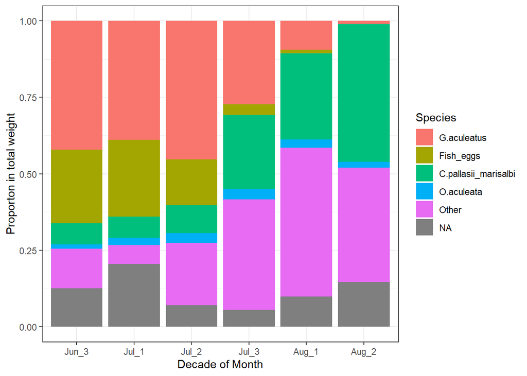

Это другой способ визуализации предыдущего графика. Этот вариант мне кажется лучше. В принципе, можно пустить его в параллель с визуализацией сезонной динамики встречаемости видов (общий ход сезонной динамики встречаемости и доли в пищевом комке похожи)

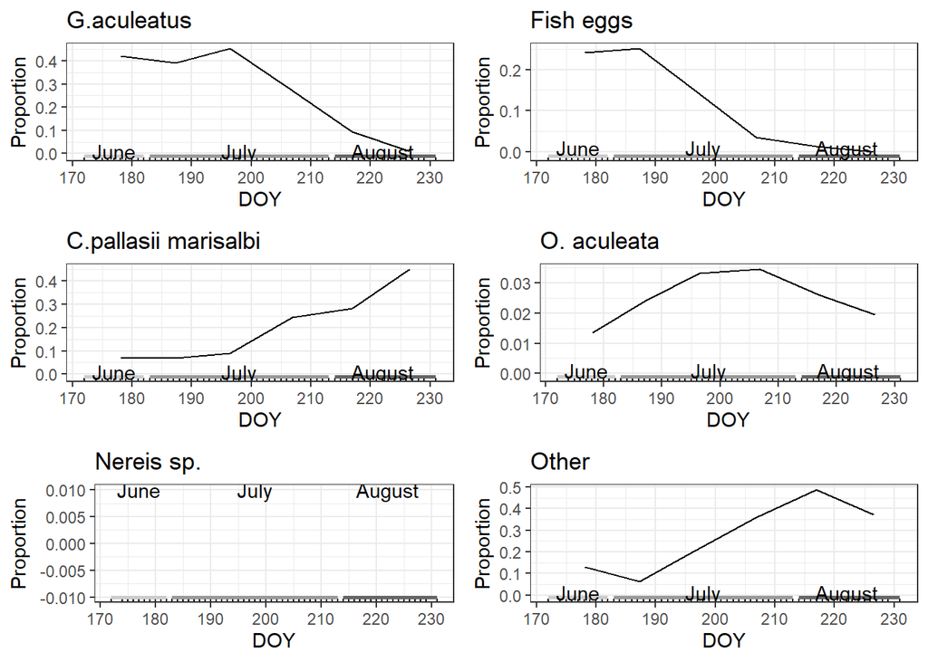

## Многолетняя динамика доли

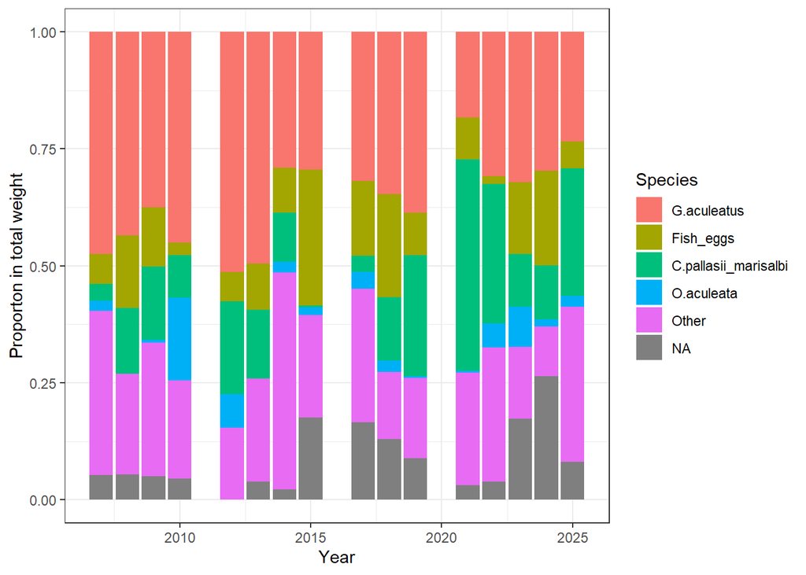

Другой вариант визуализации этого же графика. Здесь точки - исходные доли, синие линии - сглаженная тенденция.

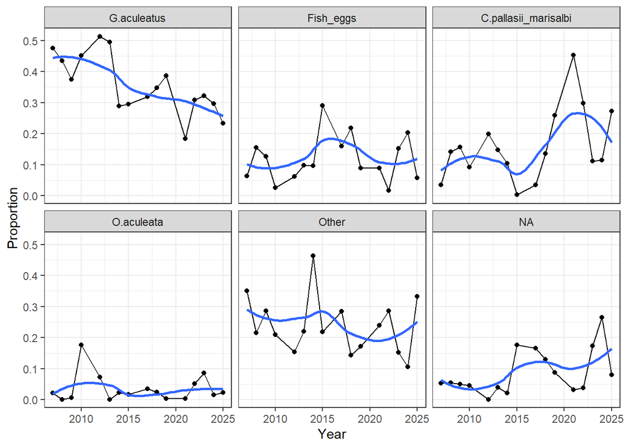